To test whether local marine species richness has changed over time, we have performed a meta-regression on the relationship between the log ratio of species richness between the final and initial time points and study duration. The weighted analysis included 212 sites from 50 studies while the unweighted analysis included 704 sites and 147 studies.

In the both the weighted and unweighted analyses, species richness did not change on average (mod1, mod2), nor was there a relationship between change in species richness and duration (mod1).

#### Human Impacts

```r
hci_rma_all <-
  rma.mv(yi = yi_SppR_ROM, V = vi_SppR_ROM,
         data = fl_combined,
         random = ~ 1 | Study.ID,
         mods = ~ Duration*mean_imps)
hci_rma_all
```

```
##
## Multivariate Meta-Analysis Model (k = 198; method: REML)
##
## Variance Components:
##
##             estim    sqrt  nlvls  fixed    factor
## sigma^2    0.0944  0.3072     47     no  Study.ID
##
## Test for Residual Heterogeneity:
## QE(df = 194) = 12685.0142, p-val < .0001
##
## Test of Moderators (coefficient(s) 2,3,4):
## QM(df = 3) = 18.4922, p-val = 0.0003
##
## Model Results:
##
##                     estimate      se     zval    pval    ci.lb    ci.ub
## intrcpt              -0.2264  0.0901  -2.5114  0.0120  -0.4030  -0.0497
## Duration              0.0076  0.0060   1.2732  0.2029  -0.0041   0.0194
## mean_imps             0.0594  0.0145   4.0940  <.0001   0.0309   0.0878
## Duration:mean_imps   -0.0022  0.0009  -2.6285  0.0086  -0.0039  -0.0006
##
## intrcpt               *
## Duration
## mean_imps           ***
## Duration:mean_imps   **
##
## ---
## Signif. codes:  0 '***' 0.001 '**' 0.01 '*' 0.05 '.' 0.1 ' ' 1
```

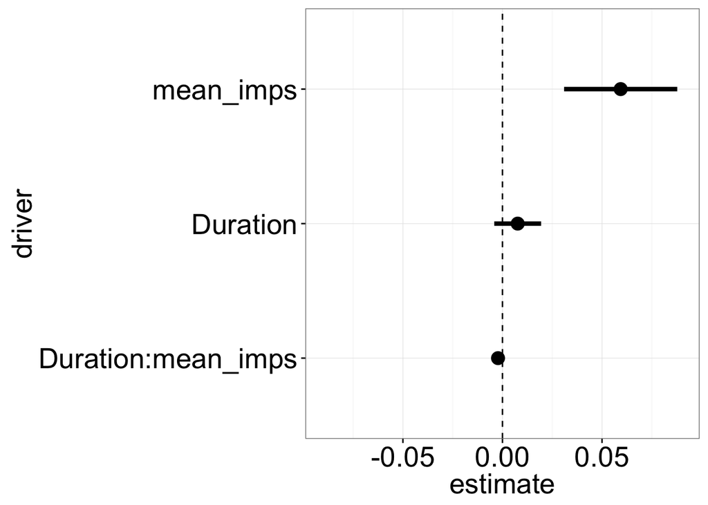

```r
mk_rma_summary_df(hci_rma_all) %>%
  filter(driver != 'intrcpt') %>%
  mutate(driver = factor(driver, levels = c('Duration:mean_imps', 'Duration', 'mean_imps'))) %>%
  ggplot(data = ., aes(x = estimate, y = driver)) +
    theme_bw() +
    geom_errorbarh(aes(xmin = ci_lb, xmax = ci_ub), height = 0, size = 1.5) +
    geom_point(size = 4) +
    geom_vline(xintercept = 0, colour = 'black', linetype = 'dashed') +
    xlim(c(-0.09, 0.09)) +
    theme(axis.text.y = element_text(hjust = 1, size = 20),
          axis.text.x = element_text(size = 20),
          axis.title = element_text(size = 20))
```

- Note: the response to human impacts is different if we exclude the data containing the studies associated with events (signs reverse)

```r
hci_rma_ne <-
  rma.mv(yi = yi_SppR_ROM, V = vi_SppR_ROM,
         data = no_event,
         random = ~ 1 | Study.ID,
         mods = ~ Duration*mean_imps)
hci_rma_ne
```

```
##
## Multivariate Meta-Analysis Model (k = 136; method: REML)
##
## Variance Components:
##
##             estim    sqrt  nlvls  fixed    factor
## sigma^2    0.0540  0.2323     33     no  Study.ID
##
## Test for Residual Heterogeneity:
## QE(df = 132) = 5728.9911, p-val < .0001
##
## Test of Moderators (coefficient(s) 2,3,4):
## QM(df = 3) = 46.3503, p-val < .0001
##
## Model Results:
##
##                     estimate      se     zval    pval    ci.lb    ci.ub
## intrcpt               0.2669  0.1373   1.9441  0.0519  -0.0022   0.5361
## Duration             -0.0361  0.0116  -3.1191  0.0018  -0.0588  -0.0134
## mean_imps            -0.0562  0.0279  -2.0165  0.0437  -0.1108  -0.0016
## Duration:mean_imps    0.0092  0.0020   4.5079  <.0001   0.0052   0.0132
##
## intrcpt               .
## Duration             **
## mean_imps             *
## Duration:mean_imps  ***
##
## ---
## Signif. codes:  0 '***' 0.001 '**' 0.01 '*' 0.05 '.' 0.1 ' ' 1
```

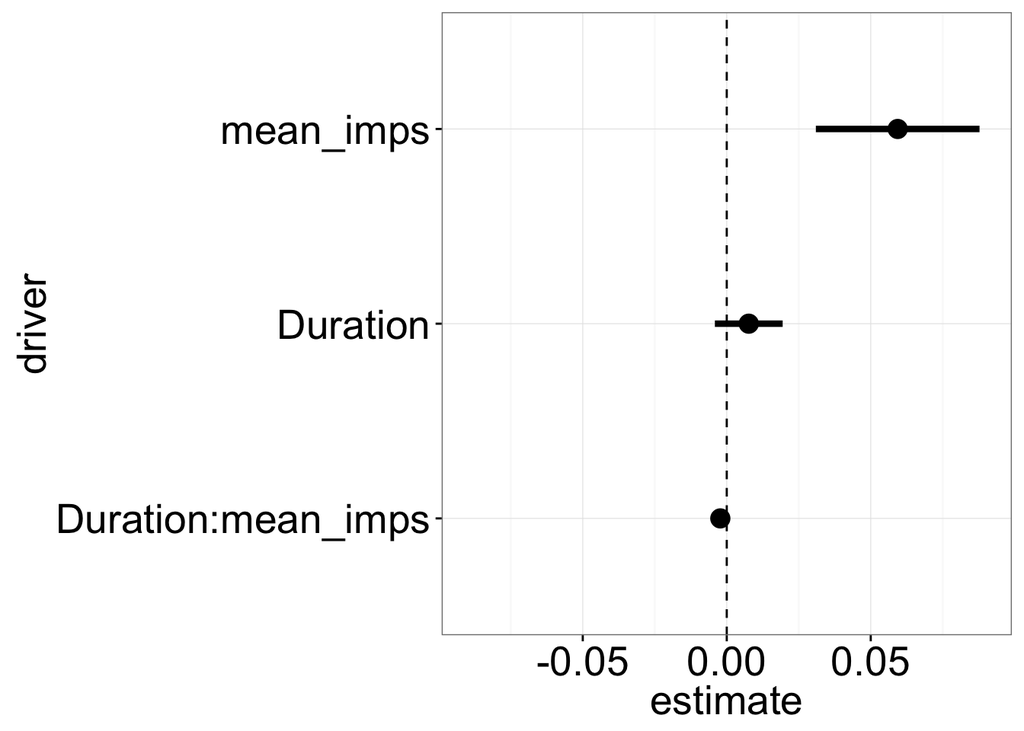

```r
mk_rma_summary_df(hci_rma_all) %>%
  filter(driver != 'intrcpt') %>%
  mutate(driver = factor(driver, levels = c('Duration:mean_imps', 'Duration', 'mean_imps'))) %>%
  ggplot(data = ., aes(x = estimate, y = driver)) +
    theme_bw() +
    geom_errorbarh(aes(xmin = ci_lb, xmax = ci_ub), height = 0, size = 1.5) +
    geom_point(size = 4) +
    geom_vline(xintercept = 0, colour = 'black', linetype = 'dashed') +
    xlim(c(-0.09, 0.09)) +
    theme(axis.text.y = element_text(hjust = 1, size = 20),
          axis.text.x = element_text(size = 20),
          axis.title = element_text(size = 20))
```

#### Full drivers model

```r
full_rma_all <-
    rma.mv(yi = yi_SppR_ROM, V = vi_SppR_ROM,
           data = fl_combined %>% mutate(scaled_invs = mean_invs * 10^-3),
          random = ~ 1 | Study.ID,
          mods = ~ Duration * SppR1 * (sliced_vocc + mean_nuts + scaled_invs)
)
full_rma_all
```

```
##
## Multivariate Meta-Analysis Model (k = 153; method: REML)
##
## Variance Components:
##
##             estim    sqrt  nlvls  fixed    factor
## sigma^2    2.2285  1.4928     33     no  Study.ID
##
## Test for Residual Heterogeneity:
## QE(df = 137) = 2956.9155, p-val < .0001
##
## Test of Moderators (coefficient(s) 2,3,4,5,6,7,8,9,10,11,12,13,14,15,16):
## QM(df = 15) = 4750.5344, p-val < .0001
##
## Model Results:
##
##                             estimate      se      zval    pval    ci.lb
## intrcpt                      -0.3172  0.3403   -0.9320  0.3513  -0.9841
## Duration                      0.0435  0.0202    2.1558  0.0311   0.0040
## SppR1                        -0.0125  0.0046   -2.7562  0.0058  -0.0215
## sliced_vocc                   0.0002  0.0004    0.5113  0.6092  -0.0006
## mean_nuts                     0.1488  0.0071   20.8811  <.0001   0.1348
## scaled_invs                  -0.0545  0.0099   -5.5184  <.0001  -0.0738
## Duration:SppR1                0.0007  0.0005    1.3804  0.1675  -0.0003
## Duration:sliced_vocc         -0.0002  0.0001   -2.5454  0.0109  -0.0003
## Duration:mean_nuts           -0.0120  0.0012   -9.8013  <.0001  -0.0144
## Duration:scaled_invs          0.0046  0.0007    6.8831  <.0001   0.0033
## SppR1:sliced_vocc             0.0000  0.0000    3.1337  0.0017   0.0000
## SppR1:mean_nuts              -0.0074  0.0004  -21.0101  <.0001  -0.0081
## SppR1:scaled_invs             0.0022  0.0004    5.5660  <.0001   0.0014
## Duration:SppR1:sliced_vocc   -0.0000  0.0000   -2.5035  0.0123  -0.0000
## Duration:SppR1:mean_nuts      0.0007  0.0001   11.9115  <.0001   0.0006
## Duration:SppR1:scaled_invs   -0.0002  0.0000   -6.0667  <.0001  -0.0003
##                               ci.ub
## intrcpt                      0.3498
## Duration                     0.0831    *
## SppR1                       -0.0036   **
## sliced_vocc                  0.0010
## mean_nuts                    0.1628  ***
## scaled_invs                 -0.0351  ***
## Duration:SppR1               0.0017
## Duration:sliced_vocc        -0.0000    *
## Duration:mean_nuts          -0.0096  ***
## Duration:scaled_invs         0.0059  ***
## SppR1:sliced_vocc            0.0000   **
## SppR1:mean_nuts             -0.0067  ***
## SppR1:scaled_invs            0.0030  ***
## Duration:SppR1:sliced_vocc  -0.0000    *
## Duration:SppR1:mean_nuts     0.0008  ***
## Duration:SppR1:scaled_invs  -0.0002  ***
##
## ---
## Signif. codes:  0 '***' 0.001 '**' 0.01 '*' 0.05 '.' 0.1 ' ' 1
```

```r
full_rma_all_summary <-
mk_rma_summary_df(full_rma_all) %>%
  #standardise_coefs(.) %>%
  filter(driver != 'intrcpt') %>%
  #filter(sig_stars != ' ') %>%
  mutate(grouping = as.character(driver)) %>%
  mutate(grouping = replace(grouping, grouping %in% c('SppR1', 'Duration', 'Duration:SppR1'), 'mods')) %>%
  mutate(grouping = replace(grouping, grouping %in% c('sliced_vocc', 'SppR1:sliced_vocc',
        'Duration:sliced_vocc', 'Duration:SppR1:sliced_vocc'), 'vocc'),
         grouping = replace(grouping, grouping %in% c('mean_nuts',
        'SppR1:mean_nuts', 'Duration:mean_nuts', 'Duration:SppR1:mean_nuts'), 'nuts'),
         grouping = replace(grouping, grouping %in% c('scaled_invs',
        'SppR1:scaled_invs', 'Duration:scaled_invs', 'Duration:SppR1:scaled_invs'), 'invs')) %>%
  mutate(driver = factor(driver, levels = c('Duration:SppR1', 'Duration', 'SppR1',
                                   'Duration:SppR1:sliced_vocc', 'Duration:sliced_vocc',
                                   'SppR1:sliced_vocc', 'sliced_vocc',
                                   'Duration:SppR1:mean_nuts', 'Duration:mean_nuts',
                                   'SppR1:mean_nuts', 'mean_nuts',
                                  'Duration:SppR1:scaled_invs', 'Duration:scaled_invs',
                                  'SppR1:scaled_invs', 'scaled_invs'
                                  ))) %>%
  mutate(sig = '*', sig = replace(sig, sig_stars == ' ', ''))
```

Initial richness:

- areas of higher species richness experience greater losses (as expected)
- yet over the long term, there is an average of species gains in the coastal areas examined in this study
- I am not sure what I think this means with the richness*duration interaction - high richness does not change the long-term outcome of species richness gain. But I do not think that this makes sense.
- stars over the points indicate these were significantly different from zero.

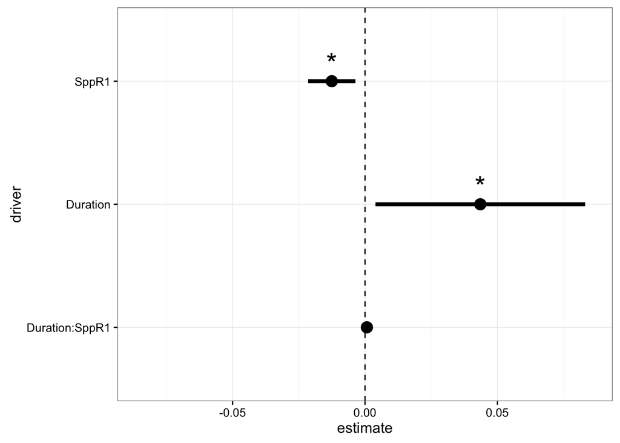

```r
full_rma_all_summary %>%
  filter(grouping == 'mods') %>%
  ggplot(data = ., aes(x = estimate, y = driver)) +
    theme_bw() +
    geom_point(size = 4) +
    geom_errorbarh(aes(y = driver, xmin = ci_lb, xmax = ci_ub), height = 0, size = 1.5) +
    geom_text(aes(x = estimate, y = driver, label = sig), hjust = 0.5, vjust = -0.4, size = 8) +
    geom_vline(xintercept = 0, colour = 'black', linetype = 'dashed') +
    xlim(c(-0.085, 0.085))
```

Nutrients

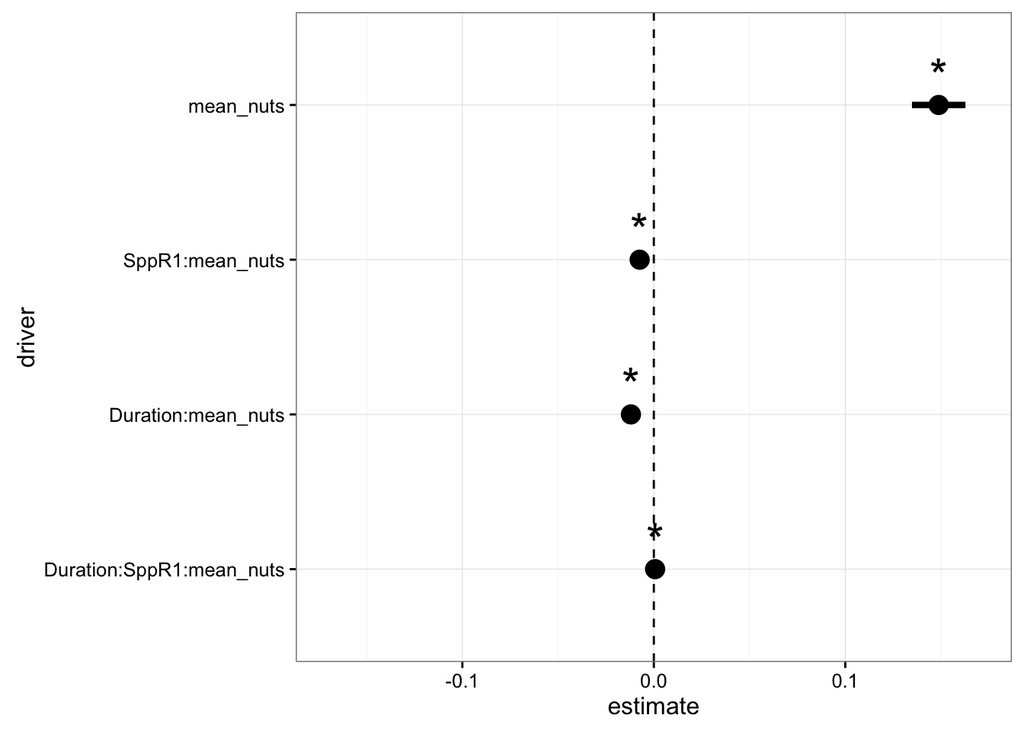

```r
full_rma_all_summary %>%
  filter(grouping == 'nuts') %>%
  ggplot(data = ., aes(x = estimate, y = driver)) +
    theme_bw() +
    geom_point(size = 4) +
    geom_errorbarh(aes(y = driver, xmin = ci_lb, xmax = ci_ub), height = 0, size = 1.5) +
    geom_text(aes(x = estimate, y = driver, label = sig), hjust = 0.5, vjust = -0.4, size = 8) +
    geom_vline(xintercept = 0, colour = 'black', linetype = 'dashed') +
    xlim(c(-0.17, 0.17))
```

### Attempt to standardize coefficients

- subset data to include only data that would be included in the model (i.e., exclude data with missing rows)

```r
sds <-
  fl_combined %>%
    filter(!is.na(yi_SppR_ROM) & !is.na(vi_SppR_ROM) & !is.na(mean_invs) & !is.na(sliced_vocc) & !is.na(mean_nuts)) %>%
    mutate(scaled_invs = mean_invs * 10^-3) %>%
    summarise(sd_yi = sd(yi_SppR_ROM),
              sd_duration = sd(Duration),
              sd_invs = sd(scaled_invs),
              sd_nuts = sd(mean_nuts),
              sd_vocc = sd(sliced_vocc),
              sd_SppR1 = sd(SppR1)
              )

std_full_rma_all <-
    rma.mv(yi = yi_SppR_ROM, V = vi_SppR_ROM,
           data =   fl_combined %>%
                    mutate(scaled_invs = mean_invs * 10^-3) %>%
                    mutate(Duration = Duration * (sds$sd_duration / sds$sd_yi),
                           scaled_invs = scaled_invs * (sds$sd_invs / sds$sd_yi),
                           mean_nuts = mean_nuts * (sds$sd_nuts / sds$sd_yi),
                           sliced_vocc = sliced_vocc * (sds$sd_vocc / sds$sd_yi),
                           SppR1 = SppR1 * (sds$sd_SppR1 / sds$sd_yi)),
          random = ~ 1 | Study.ID,
          mods = ~ Duration * SppR1 * (sliced_vocc + mean_nuts + scaled_invs)
)
std_full_rma_all


fl_combined %>%
  mutate(scaled_invs = mean_invs * 10^-2) %>%
  mutate(Duration = Duration * (sds$sd_duration / sds$sd_yi),
         scaled_invs = scaled_invs * (sds$sd_invs / sds$sd_yi),
         mean_nuts = mean_nuts * (sds$sd_nuts / sds$sd_yi),
         sliced_vocc = sliced_vocc * (sds$sd_vocc / sds$sd_yi),
         SppR1 = SppR1 * (sds$sd_SppR1 / sds$sd_yi)) %>%
  filter(!is.na(yi_SppR_ROM) & !is.na(vi_SppR_ROM) & !is.na(mean_invs) & !is.na(sliced_vocc) & !is.na(mean_nuts)) %>%
  select(Duration, scaled_invs, mean_nuts, sliced_vocc, SppR1) %>%
  cov()
```

[output not shown]

#### Events

As expected, in the short-term, sites that were associated with positive events in species richness had increases in species richness. The same was true with studies that were associated with events classified as ‘uncertain’.

```r
localmod <-
  rma.mv(yi = yi_SppR_ROM, V = vi_SppR_ROM, data = event,
         random = ~ 1 | factor(Study.ID),
         mods = ~ Duration:expected_change + expected_change + 0)
localmod
```

```
##
## Multivariate Meta-Analysis Model (k = 60; method: REML)
##
## Variance Components:
##
##             estim    sqrt  nlvls  fixed            factor
## sigma^2    0.0816  0.2857     24     no  factor(Study.ID)
##
## Test for Residual Heterogeneity:
## QE(df = 54) = 1171.3058, p-val < .0001
##
## Test of Moderators (coefficient(s) 1,2,3,4,5,6):
## QM(df = 6) = 37.5809, p-val < .0001
##
## Model Results:
##
##                                    estimate      se     zval    pval
## expected_changeNegative             -0.0754  0.1589  -0.4743  0.6353
## expected_changePositive              0.3333  0.1539   2.1653  0.0304
## expected_changeUncertain             0.2785  0.1233   2.2579  0.0240
## Duration:expected_changeNegative    -0.0024  0.0179  -0.1314  0.8954
## Duration:expected_changePositive    -0.0491  0.0195  -2.5155  0.0119
## Duration:expected_changeUncertain   -0.0145  0.0048  -3.0184  0.0025
##                                      ci.lb    ci.ub
## expected_changeNegative            -0.3869   0.2361
## expected_changePositive             0.0316   0.6349   *
## expected_changeUncertain            0.0367   0.5202   *
## Duration:expected_changeNegative   -0.0375   0.0328
## Duration:expected_changePositive   -0.0873  -0.0108   *
## Duration:expected_changeUncertain  -0.0239  -0.0051  **
##
## ---
## Signif. codes:  0 '***' 0.001 '**' 0.01 '*' 0.05 '.' 0.1 ' ' 1
```

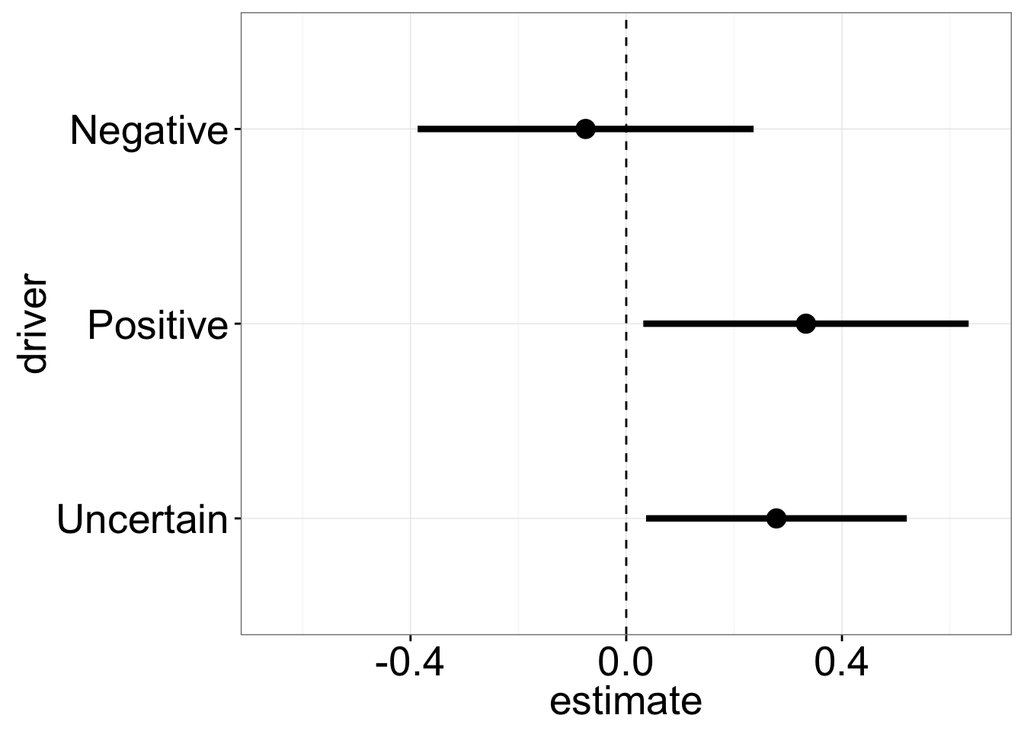

```r
# Short-term
mk_rma_summary_df(localmod) %>%
  mutate(driver = factor(c('Negative', 'Positive', 'Uncertain', 'Dur*Negative',
                      'Dur*Positive', 'Dur*Uncertain'),
                        levels = c('Uncertain', 'Positive', 'Negative',
                        'Dur*Uncertain', 'Dur*Positive', 'Dur*Negative'))) %>%
  filter(driver %in% c('Negative', 'Positive', 'Uncertain')) %>%
  ggplot(data = ., aes(x = estimate, y = driver)) +
  theme_bw() +
  geom_point(size = 4) +
  geom_errorbarh(aes(y = driver, xmin = ci_lb, xmax = ci_ub), height = 0, size = 1.5) +
  geom_vline(xintercept = 0, colour = 'black', linetype = 'dashed') +
  xlim(c(-0.65, 0.65)) +
  theme(axis.text.y = element_text(hjust = 1, size = 20),
      axis.text.x = element_text(size = 20),
      axis.title = element_text(size = 20))
```

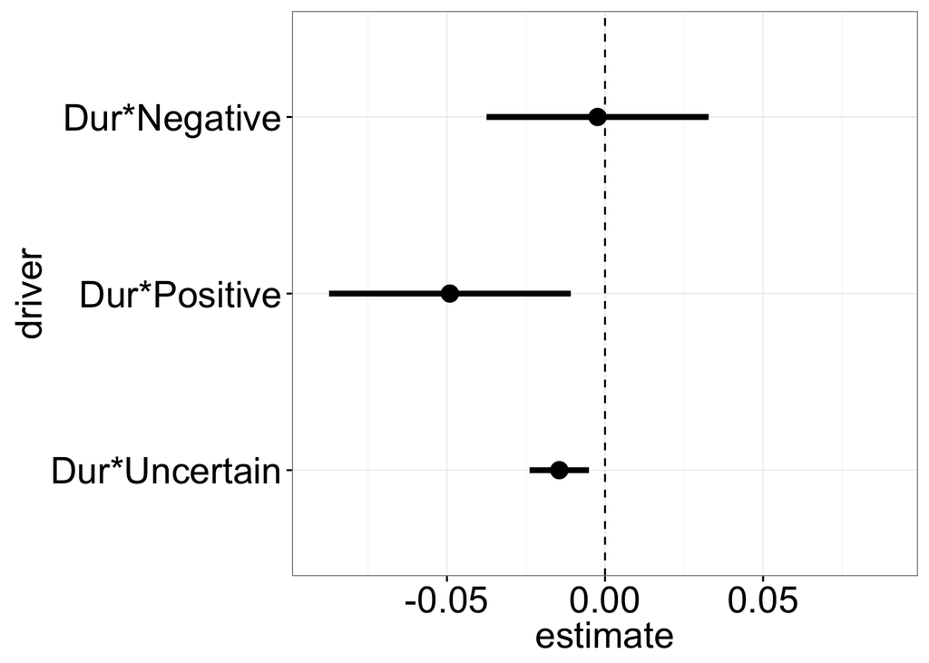

```r
# Long-term
mk_rma_summary_df(localmod) %>%
  mutate(driver = factor(c('Negative', 'Positive', 'Uncertain', 'Dur*Negative',
                      'Dur*Positive', 'Dur*Uncertain'),
                        levels = c('Uncertain', 'Positive', 'Negative',
                        'Dur*Uncertain', 'Dur*Positive', 'Dur*Negative'))) %>%
  filter(driver %in% c('Dur*Negative', 'Dur*Positive', 'Dur*Uncertain')) %>%
  ggplot(data = ., aes(x = estimate, y = driver)) +
  theme_bw() +
  geom_point(size = 4) +
  geom_errorbarh(aes(y = driver, xmin = ci_lb, xmax = ci_ub), height = 0, size = 1.5) +
  geom_vline(xintercept = 0, colour = 'black', linetype = 'dashed') +
  xlim(c(-0.09, 0.09)) +
  theme(axis.text.y = element_text(hjust = 1, size = 20),
      axis.text.x = element_text(size = 20),
      axis.title = element_text(size = 20))
```